# Rootograms for count regressions

Author

Maciej Beręsewicz

## 1 Introduction

A **rootogram** (Tukey, 1977; Kleiber & Zeileis, 2016) is a graphical goodness-of-fit display for count models. For each observed count $k$ it compares

- the **observed frequency** $n_k = \#\{i : y_i = k\}$,
- the **expected frequency** under the fitted model $\hat n_k = \sum_{i=1}^{n} \hat P(Y_i = k \mid \mathbf{x}_i;\hat{\boldsymbol\theta})$.

In a **hanging** rootogram the bar of height $\sqrt{n_k}$ hangs from the curve $\sqrt{\hat n_k}$, so its bottom sits at $\sqrt{\hat n_k} - \sqrt{n_k}$. The square-root scale stretches the tails so small frequencies are still visible. Reading the picture is easy:

- bar bottom on the zero line → model fits this count perfectly,
- bar bottom **below** zero → model **under-predicts** that count (the data have more cases than expected),
- bar bottom **above** zero → model **over-predicts**.

In R rootograms are available via the `topmodels` package (successor to `countreg`) and accept any fitted count model (`glm`, `glm.nb`, `hurdle`, `zeroinfl`, …). In Python there is no mainstream package that does this, so we write a small helper that reproduces what `topmodels::rootogram` shows.

## 2 Setup

**R**

```r
## install.packages("topmodels", repos = "https://R-Forge.R-project.org")
#remotes::install_svn("svn://R-Forge.R-project.org/svnroot/topmodels/pkg/topmodels")

library(topmodels)
library(MASS)
library(here)
```

**Python**

```python
import numpy as np
import pandas as pd
import statsmodels.api as sm
import statsmodels.formula.api as smf
from scipy.stats import poisson, nbinom
import matplotlib.pyplot as plt
```

## 3 Data

We reuse the Polish Job Vacancy Survey (`vacancies` per company), the same dataset as in lecture 9.

**R**

```r
df <- read.csv(here("data/polish-jvs.csv"),
               colClasses = c("character", "factor", rep("character", 4), "numeric"))
df$size   <- factor(df$size,   levels = c("Large", "Medium", "Small"))
df$public <- factor(df$public)
df$nace   <- factor(df$nace)
```

**Python**

```python
from pathlib import Path
csv_path = Path("data/polish-jvs.csv")
if not csv_path.exists():
    csv_path = Path("../../data/polish-jvs.csv")

df = pd.read_csv(csv_path,
                 dtype={"id": np.int64, "woj": str, "public": str,
                        "size": str, "nace_division": str, "nace": str})
df["size"] = pd.Categorical(df["size"], categories=["Large", "Medium", "Small"])
```

## 4 Fit Poisson and Negative Binomial models

**R**

```r
pois <- glm(vacancies ~ size + public + nace, data = df,
            family = poisson(link = "log"))
nb2  <- MASS::glm.nb(vacancies ~ size + public + nace, data = df)
```

**Python**

```python
pois = smf.glm("vacancies ~ C(size) + C(public) + C(nace)", data=df,
               family=sm.families.Poisson()).fit()

# Joint MLE for NB2 (matches MASS::glm.nb)
start = np.append(pois.params.values, 1.0)
nb2 = smf.negativebinomial("vacancies ~ C(size) + C(public) + C(nace)",
                           data=df).fit(start_params=start,
                                        method="bfgs", maxiter=500, disp=0)
```

## 5 Rootograms

We display counts up to $k = 20$. Vacancies in the JVS are very right-skewed (≈ 80% zeros, mean ≈ 1, max in the hundreds), so 20 is enough to show what matters: zeros, the small-count region, and the beginning of the tail.

### 5.1 R — `topmodels::rootogram`

`topmodels::rootogram()` takes a fitted model and produces a hanging rootogram by default.

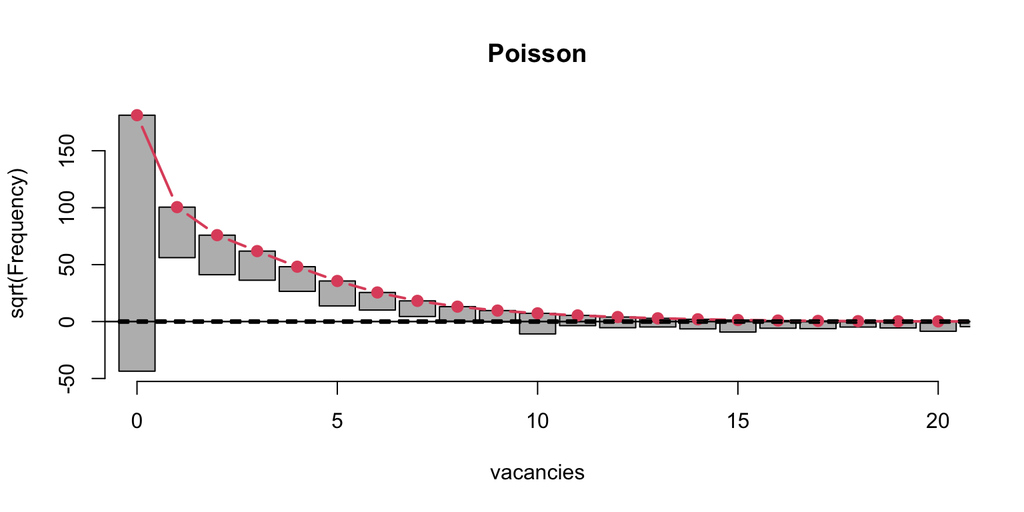

```r
rootogram(pois, plot = TRUE,
          main = "Poisson",
          xlim = c(0,20))
```

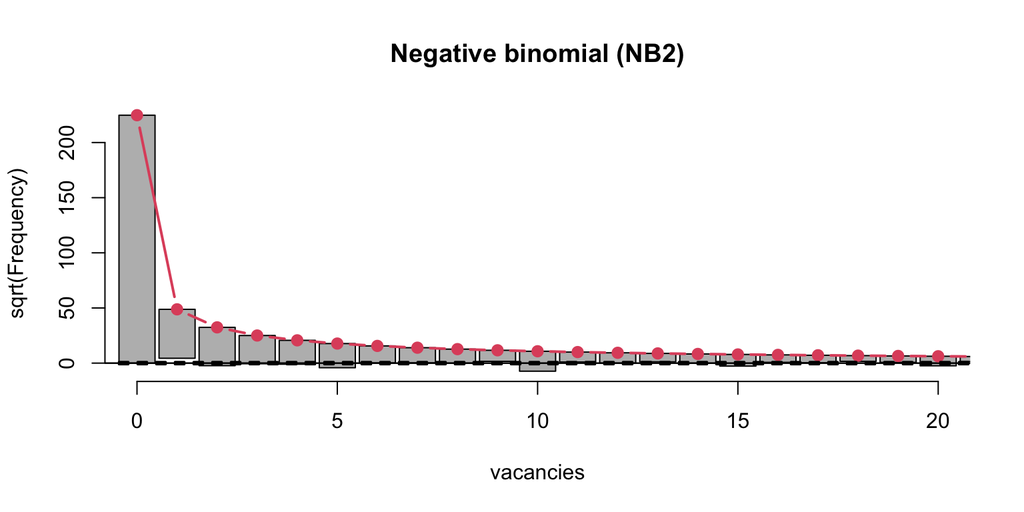

```r
rootogram(nb2, plot = TRUE,
          main = "Negative binomial (NB2)",
          xlim = c(0,20))
```

### 5.2 Python — manual implementation

Same recipe as `topmodels`: observed counts, expected counts on the $\sqrt{\cdot}$ scale, bars hanging from the expected curve. The expected count for value $k$ is the **sum across observations** of the fitted PMF evaluated at $k$.

For NB2, statsmodels parametrises overdispersion via $\alpha = 1/\theta$ so $\operatorname{Var}(Y) = \mu + \alpha\mu^2$. To map to `scipy.stats.nbinom(n, p)` use $n = 1/\alpha$ and $p = n/(n + \mu)$.

```python
def rootogram(model, y, max_count=20, dist="poisson", ax=None,
              title=None):
    """Hanging rootogram for a fitted Poisson or NB2 GLM.

    model : statsmodels results object with .predict() returning fitted means
    y     : observed response (1d array-like of non-negative ints)
    dist  : "poisson" or "nbinom"
    """
    mu = np.asarray(model.predict())
    y  = np.asarray(y)
    ks = np.arange(max_count + 1)

    observed = np.array([(y == k).sum() for k in ks], dtype=float)

    if dist == "poisson":
        expected = np.array([poisson.pmf(k, mu).sum() for k in ks])
    elif dist == "nbinom":
        alpha = float(model.params["alpha"])
        n = 1.0 / alpha
        p = n / (n + mu)
        expected = np.array([nbinom.pmf(k, n, p).sum() for k in ks])
    else:
        raise ValueError("dist must be 'poisson' or 'nbinom'")

    obs_root = np.sqrt(observed)
    exp_root = np.sqrt(expected)

    if ax is None:
        _, ax = plt.subplots(figsize=(8, 4))

    ax.bar(ks, obs_root, bottom=exp_root - obs_root, width=0.7,
           color="lightgray", edgecolor="black", label="observed")
    ax.plot(ks, exp_root, "ro-", linewidth=1.5, markersize=4,
            label=r"$\sqrt{\mathrm{expected}}$")
    ax.axhline(0, color="black", linewidth=0.8)
    ax.set_xlabel("count")
    ax.set_ylabel(r"$\sqrt{\mathrm{frequency}}$")
    ax.set_xticks(ks[::2])
    if title:
        ax.set_title(title)
    ax.legend(loc="upper right")
    return ax
```

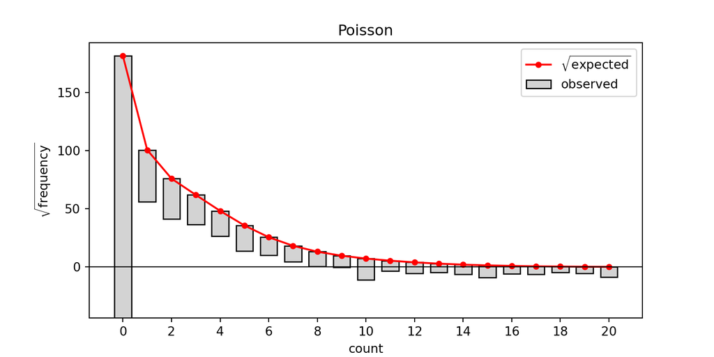

```python
fig, ax = plt.subplots(figsize=(8, 4))
rootogram(pois, df["vacancies"], dist="poisson", ax=ax, title="Poisson")
plt.show()
```

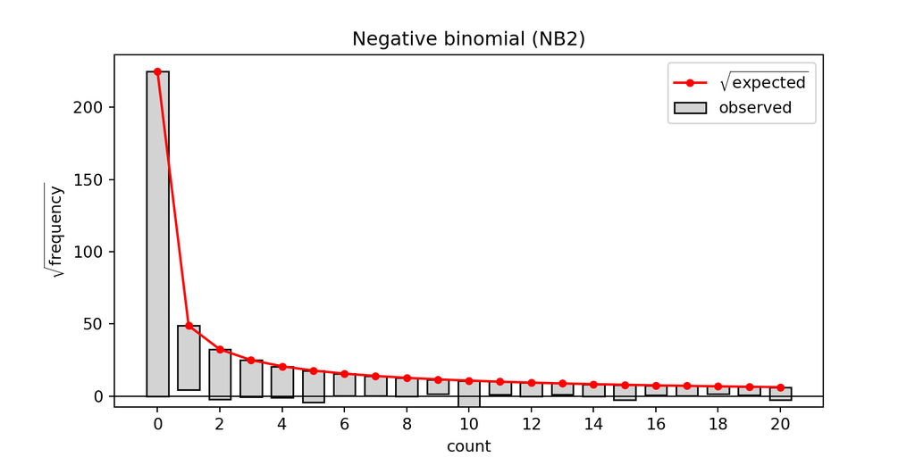

```python
fig, ax = plt.subplots(figsize=(8, 4))
rootogram(nb2, df["vacancies"], dist="nbinom", ax=ax,
          title="Negative binomial (NB2)")
plt.show()
```

## 6 Numerical comparison

The picture is also visible in the raw observed/expected counts.

**R**

```r
ks <- 0:10
obs <- as.numeric(table(factor(df$vacancies, levels = ks)))

mu_p <- predict(pois, type = "response")
exp_p <- sapply(ks, function(k) sum(dpois(k, lambda = mu_p)))

mu_n  <- predict(nb2, type = "response")
theta <- nb2$theta
exp_n <- sapply(ks, function(k) sum(dnbinom(k, mu = mu_n, size = theta)))

round(data.frame(k = ks,
                 observed   = obs,
                 exp_pois   = exp_p,
                 exp_nb2    = exp_n,
                 diff_pois  = obs - exp_p,
                 diff_nb2   = obs - exp_n), 1)
```

| k | observed | exp_pois | exp_nb2 | diff_pois | diff_nb2 |
| --- | --- | --- | --- | --- | --- |
| 0 | 50551 | 32844.7 | 50527.0 | 17706.3 | 24.0 |
| 1 | 1969 | 10099.1 | 2378.4 | -8130.1 | -409.4 |
| 2 | 1207 | 5756.6 | 1051.4 | -4549.6 | 155.6 |
| 3 | 655 | 3828.6 | 626.7 | -3173.6 | 28.3 |
| 4 | 469 | 2320.8 | 427.2 | -1851.8 | 41.8 |
| 5 | 480 | 1270.2 | 314.5 | -790.2 | 165.5 |
| 6 | 239 | 652.7 | 243.6 | -413.7 | -4.6 |
| 7 | 189 | 330.3 | 195.5 | -141.3 | -6.5 |
| 8 | 163 | 171.6 | 161.0 | -8.6 | 2.0 |
| 9 | 101 | 93.2 | 135.4 | 7.8 | -34.4 |
| 10 | 327 | 52.1 | 115.7 | 274.9 | 211.3 |

**Python**

```python
ks = np.arange(11)
obs = np.array([(df["vacancies"] == k).sum() for k in ks], dtype=float)

mu_p  = pois.predict()
exp_p = np.array([poisson.pmf(k, mu_p).sum() for k in ks])

alpha = float(nb2.params["alpha"])
n_par = 1.0 / alpha
mu_n  = nb2.predict()
p_par = n_par / (n_par + mu_n)
exp_n = np.array([nbinom.pmf(k, n_par, p_par).sum() for k in ks])

pd.DataFrame({"k": ks,
              "observed":  obs,
              "exp_pois":  exp_p,
              "exp_nb2":   exp_n,
              "diff_pois": obs - exp_p,
              "diff_nb2":  obs - exp_n}).round(1)
```

```
     k  observed  exp_pois  exp_nb2  diff_pois  diff_nb2
0    0   50551.0   32844.7  50527.1    17706.3      23.9
1    1    1969.0   10099.1   2378.5    -8130.1    -409.5
2    2    1207.0    5756.6   1051.4    -4549.6     155.6
3    3     655.0    3828.6    626.8    -3173.6      28.2
4    4     469.0    2320.8    427.2    -1851.8      41.8
5    5     480.0    1270.2    314.6     -790.2     165.4
6    6     239.0     652.7    243.6     -413.7      -4.6
7    7     189.0     330.3    195.5     -141.3      -6.5
8    8     163.0     171.6    161.0       -8.6       2.0
9    9     101.0      93.2    135.4        7.8     -34.4
10  10     327.0      52.1    115.7      274.9     211.3
```

## 7 What the rootograms tell us

Both models have the same mean structure (Poisson QMLE and NB2 give nearly identical $\hat{\boldsymbol\beta}$, see notebook 09a), but they imply different distributions:

- **Poisson** badly **under-predicts the zeros** (bars dip well below the line at $k = 0$) and **over-predicts** the small positive counts ($k = 1, 2, 3$). This is the signature of overdispersion: the Poisson variance $\operatorname{Var}(Y) = \mu$ is too small, so mass gets concentrated near $\mu$ instead of being spread over zeros and the long tail.
- **NB2** has $\operatorname{Var}(Y) = \mu + \mu^2/\theta$. The extra variance lets it match the zeros and the right tail. Bar bottoms sit much closer to the zero line.

Conclusion (consistent with notebook 09a): use **NB2** (or another distribution with extra variance) when you need the **distribution** of $Y$ — for example to predict the proportion of firms with zero vacancies, or to simulate from the fitted model. For the **mean** $E(Y \mid X)$ alone, Poisson with robust standard errors is enough.

## 8 References

- Tukey, J. W. (1977). *Exploratory Data Analysis*. Addison-Wesley.
- Kleiber, C., & Zeileis, A. (2016). Visualizing count data regressions using rootograms. *The American Statistician*, 70(3), 296–303. https://doi.org/10.1080/00031305.2016.1173590
- Zeileis, A., Lang, M. N., & Stauffer, R. (2024). *topmodels: Infrastructure for Forecasting and Assessment of Probabilistic Models*. R package, https://topmodels.R-Forge.R-project.org/.